# STATS 32 Session 3: Data Visualization

Kenneth Tay

Oct 10, 2017

# Recap of week 1

- Basics of R
- Data structures
  - Homoegeneous: vectors & matrices
  - Hetergeneous: list & data frames
- Functions & packages

# Vectors

```r
vec <- c("a", "b", "c")
vec
```

```
## [1] "a" "b" "c"
```

```r
vec[c(2,4)]
```

```
## [1] "b" NA
```

# Matrices

```r
M <- matrix(letters, nrow = 3, byrow = TRUE)
M
```

```
##      [,1] [,2] [,3] [,4] [,5] [,6] [,7] [,8] [,9]
## [1,] "a"  "b"  "c"  "d"  "e"  "f"  "g"  "h"  "i"
## [2,] "j"  "k"  "l"  "m"  "n"  "o"  "p"  "q"  "r"
## [3,] "s"  "t"  "u"  "v"  "w"  "x"  "y"  "z"  "a"
```

```r
M[2:3, -1]
```

```
##      [,1] [,2] [,3] [,4] [,5] [,6] [,7] [,8]
## [1,] "k"  "l"  "m"  "n"  "o"  "p"  "q"  "r"
## [2,] "t"  "u"  "v"  "w"  "x"  "y"  "z"  "a"
```

# Lists

```r
classes <- list(quarter = "Fall 2017/18",
             ID = c("STATS 32", "STATS 101", "STATS 200"),
             credits = 12)
classes$ID
```

```
## [1] "STATS 32"  "STATS 101" "STATS 200"
```

```r
classes[["credits"]]
```

```
## [1] 12
```

# Data frames

A special type of list:

- list keys are variable names of the dataset
- list values are all vectors of the same length (no. of observations)

```r
data(mtcars)
str(mtcars)
```

```
## 'data.frame':    32 obs. of  11 variables:
##  $ mpg : num  21 21 22.8 21.4 18.7 18.1 14.3 24.4 22.8 19.2 ...
##  $ cyl : num  6 6 4 6 8 6 8 4 4 6 ...
##  $ disp: num  160 160 108 258 360 ...
##  $ hp  : num  110 110 93 110 175 105 245 62 95 123 ...
##  $ drat: num  3.9 3.9 3.85 3.08 3.15 2.76 3.21 3.69 3.92 3.92 ...
##  $ wt  : num  2.62 2.88 2.32 3.21 3.44 ...
##  $ qsec: num  16.5 17 18.6 19.4 17 ...
##  $ vs  : num  0 0 1 1 0 1 0 1 1 1 ...
##  $ am  : num  1 1 1 0 0 0 0 0 0 0 ...
##  $ gear: num  4 4 4 3 3 3 3 4 4 4 ...
##  $ carb: num  4 4 1 1 2 1 4 2 2 4 ...
```

# Getting a feel for your data

- `str`, `summary`
- `head`, `tail`
- `names`, `dim`, `nrow`, `ncol`
- `table`
- `mean`, `median`, `sd`, `var`
- `factor`, `levels`

# Agenda for today

- Different kinds of plots
- Plotting the `ggplot2` way
- Case study: `diamonds` dataset

# Words vs. pictures

*“The simple graph has brought more information to the data analyst’s mind than any other device.”* - John Tukey

```
##     mpg weight cylinders
## 1  21.0  2.620         6
## 2  21.0  2.875         6
## 3  22.8  2.320         4
## 4  21.4  3.215         6
## 5  18.7  3.440         8
## 6  18.1  3.460         6
## 7  14.3  3.570         8
## 8  24.4  3.190         4
## 9  22.8  3.150         4
## 10 19.2  3.440         6
## 11 17.8  3.440         6
## 12 16.4  4.070         8
## 13 17.3  3.730         8
## 14 15.2  3.780         8
```

[output cut: 18 more lines]

# Two classes of variables in statistics

- **Continuous variable**: Variable takes on values which fall on the real number line (or part of it)
  - E.g. height, exam score, attendance count
- **Categorical variable**: Variable takes on values which fall into discrete categories
  - E.g. ice-cream flavor, country of origin

# Barplots: counts for a categorical variable

*What is the distribution of cylinders in my dataset?*

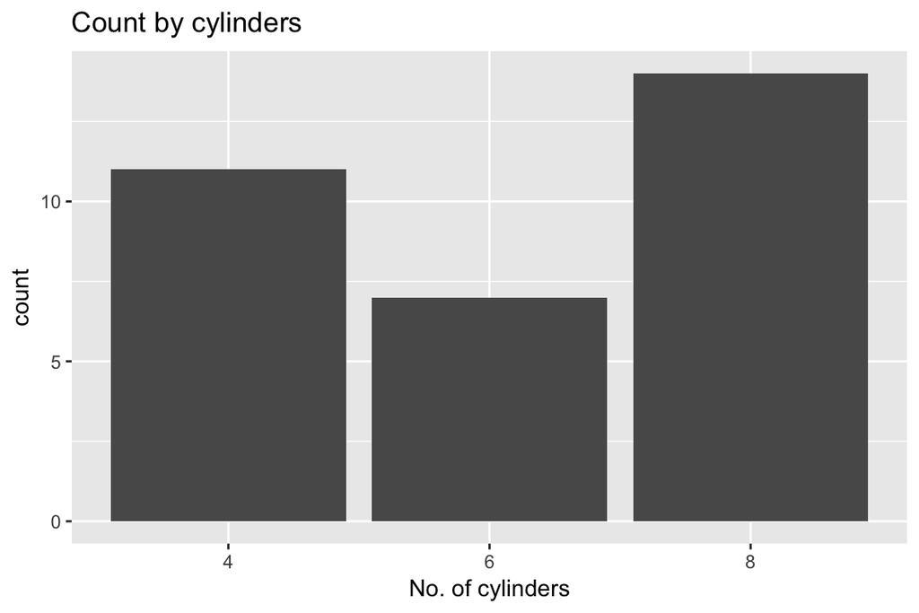

# Histograms: counts for a continuous variable

*What is the distribution of `miles per gallon` in my dataset?*

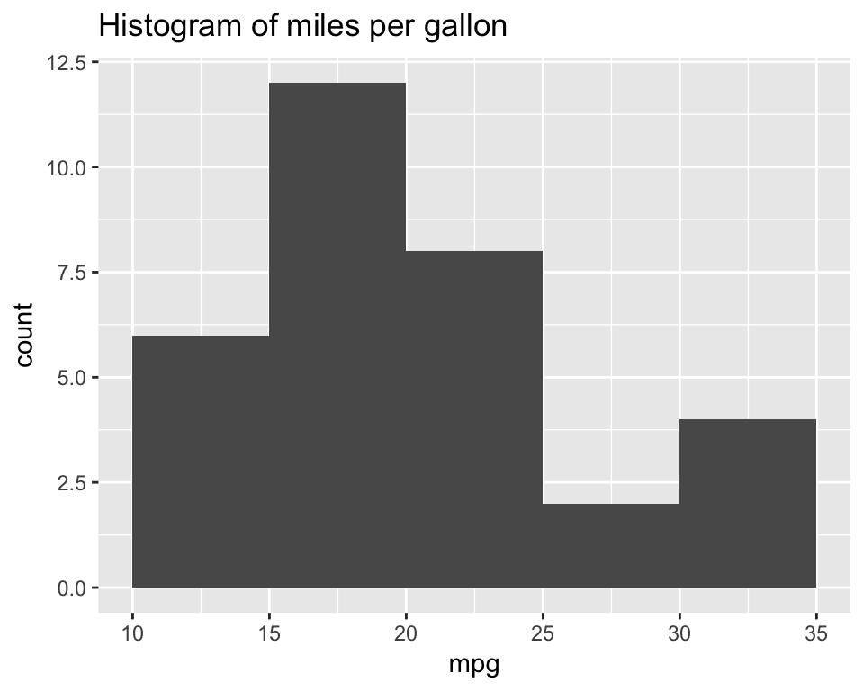

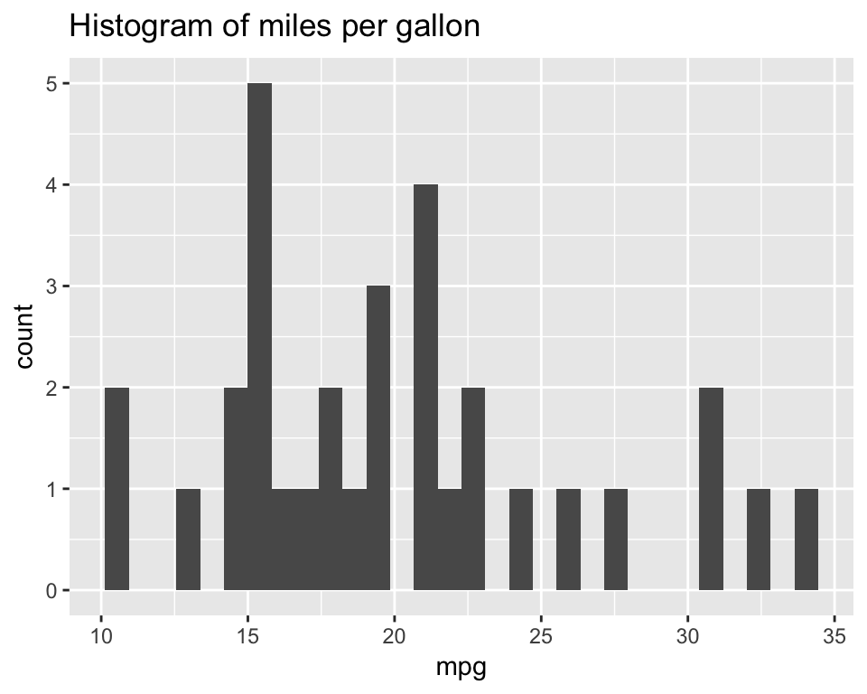

# Scatterplots: continuous variable vs. continuous variable

*What is the relationship between `mpg` and `weight`?*

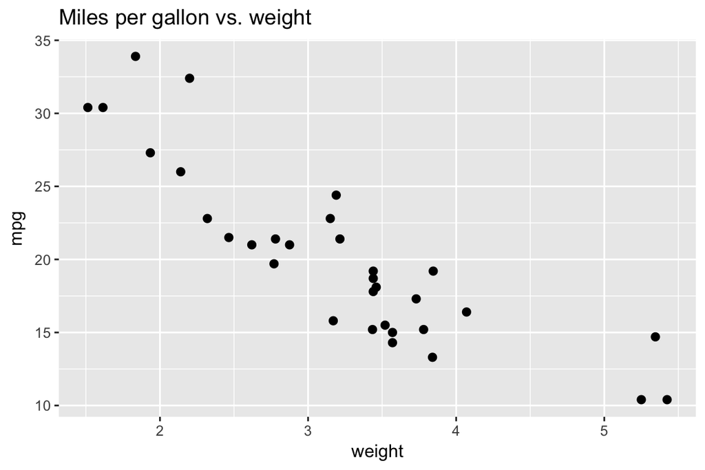

# Lineplots: continuous variable vs. time variable

*What is the relationship between `mpg` and time?*

**Not so good…**

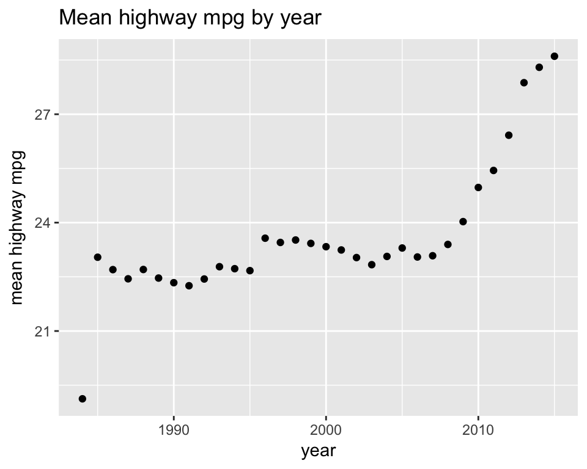

**Easier to see the trend**

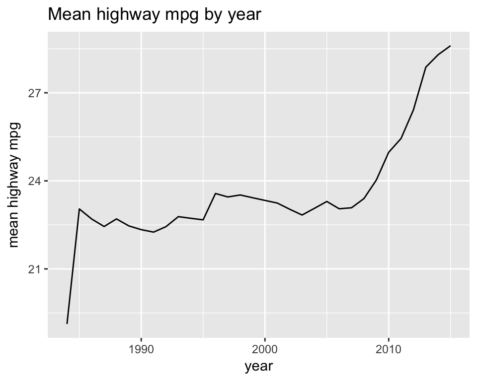

# Boxplots & violin plots: continuous variable vs. categorical variable

*For each value of cylinder, what is the distribution of `mpg` like?*

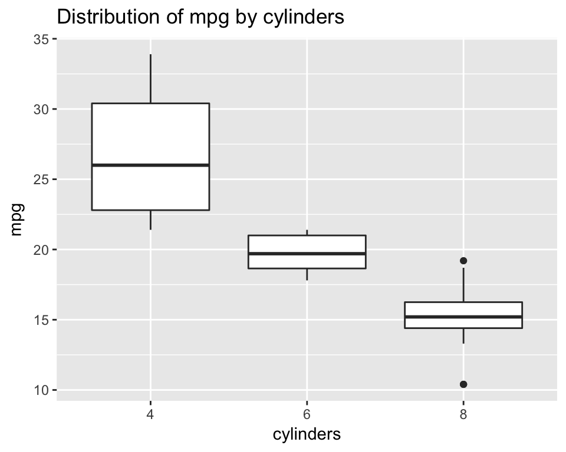

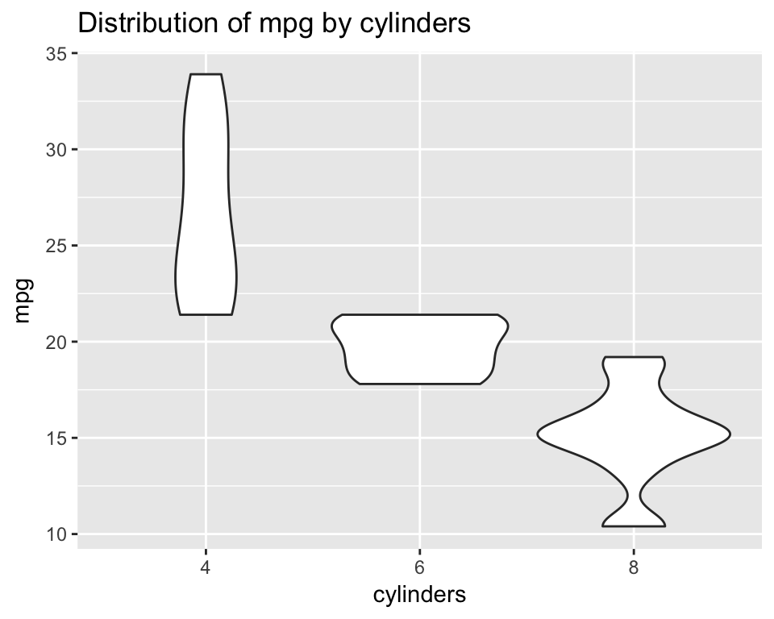

# We can combine multiple plots in one graphic

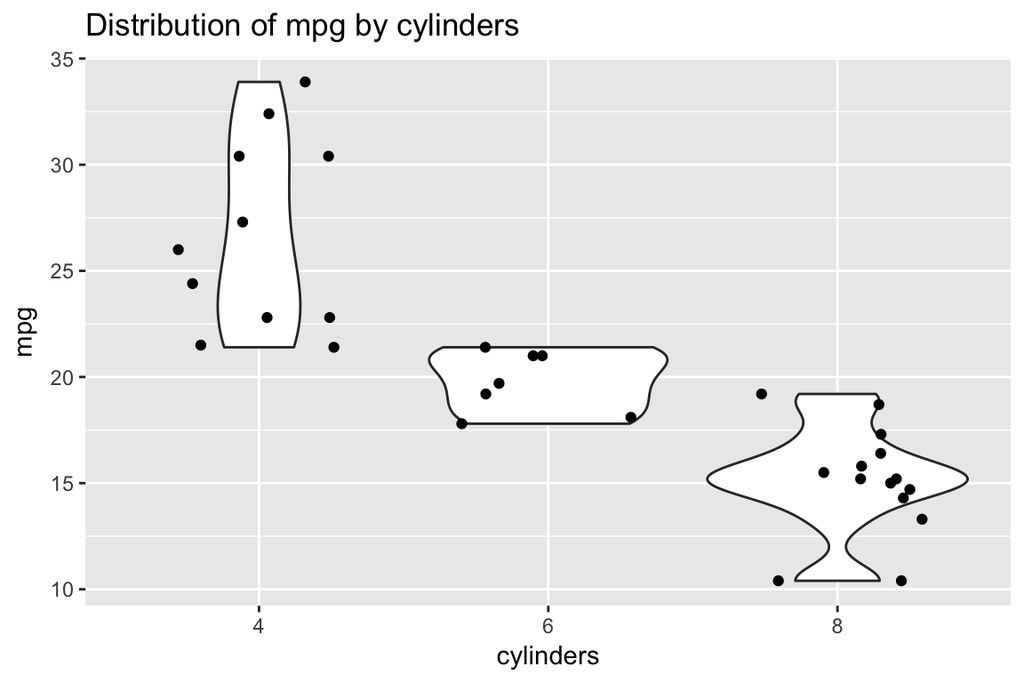

# We can combine multiple plots in one graphic

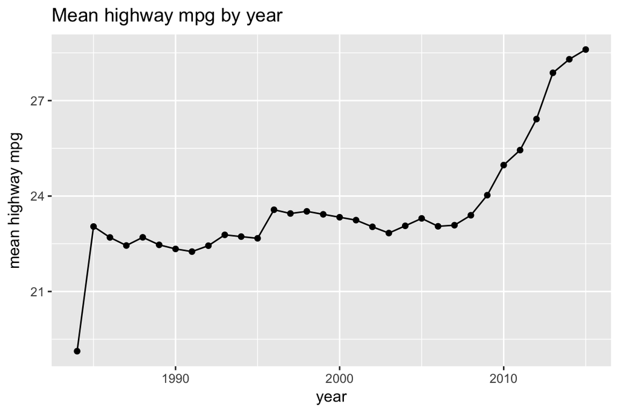

# Summary

- 1 categorical variable: barplot
- 1 continuous variable: histogram
- Continuous vs. continuous: scatterplot
- Continuous vs. time: lineplot
- Continuous vs. categorical: boxplots & violin plots

### Case study

I have father-son pairs. For each pair, I record their height and weight, as well as their ethnicities. I want to study the relationship between characteristics of the father and that of the son. What plots could help me?

# Data visualization in R: 2 broad approaches

### base R

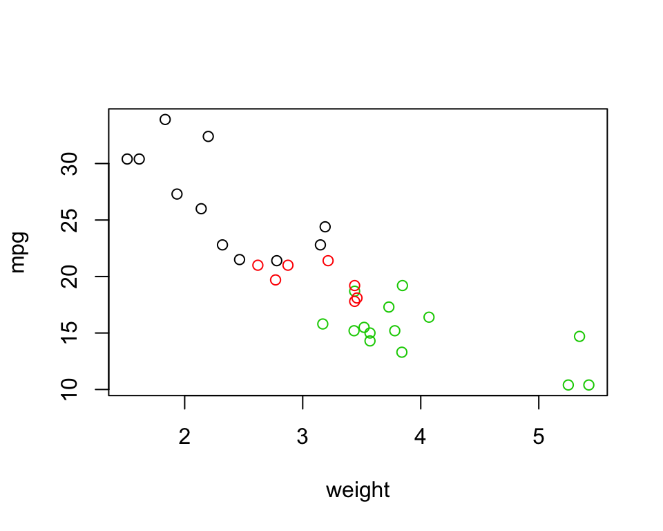

### `ggplot2`

# How can we describe a graphic?

- *The Grammar of Graphics*, by Leland Wilkinson (1999)
- Motivating example: language
  - **Grammar**: “a formal system of rules for generating lawful statements in a language”
- **Can we develop similar rules for generating plots? Yes!**
- Refined by Hadley Wickham’s “[A Layered Grammar of Graphics](http://vita.had.co.nz/papers/layered-grammar.pdf)” (2010)
  - operationalized as `ggplot2` package
  - “official” [cheat sheet](https://www.rstudio.com/resources/cheatsheets/) available
  - [`ggplot2` reference manual](http://ggplot2.tidyverse.org/reference/)

[figure not shown]

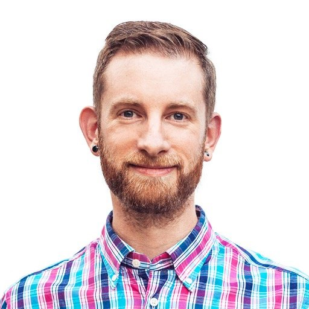

Hadley Wickham

# 3 essential elements of graphics: data, geometries, aesthetics

**Data**: Dataset we are using for the plot

A transformation of the `mtcars` dataset

```r
head(df, n = 10)
```

```
##     mpg weight cylinders
## 1  21.0  2.620         6
## 2  21.0  2.875         6
## 3  22.8  2.320         4
## 4  21.4  3.215         6
## 5  18.7  3.440         8
## 6  18.1  3.460         6
## 7  14.3  3.570         8
## 8  24.4  3.190         4
## 9  22.8  3.150         4
## 10 19.2  3.440         6
```

# 3 essential elements of graphics: data, geometries, aesthetics

**Geom**etries: Visual elements used for our data

- E.g. point, line, histogram, bar, boxplot

Geom: point

# 3 essential elements of graphics: data, geometries, aesthetics

**Aes**thetics: Defines the data columns which affect various aspects of the geom

- E.g. x, y, color, fill, size, alpha, line type, line width
- Which **aes**thetics you use depend on the **geom**etries you choose

3 different aesthetics:

- x-axis: weight
- y-axis: mpg
- color: cylinders
- shape, size, etc. take on default values, not determined by data

# Examples of other aesthetics

- x-axis: weight
- y-axis: mpg
- size: cylinders
- alpha: weight

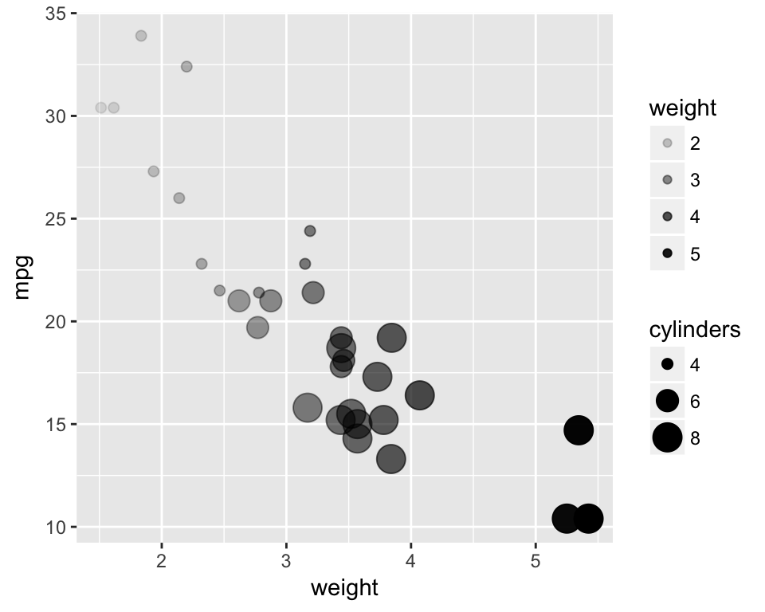

# Examples of other aesthetics

- x-axis: weight
- y-axis: mpg
- color: cylinders
- shape: cylinders

ggplot2 shapes

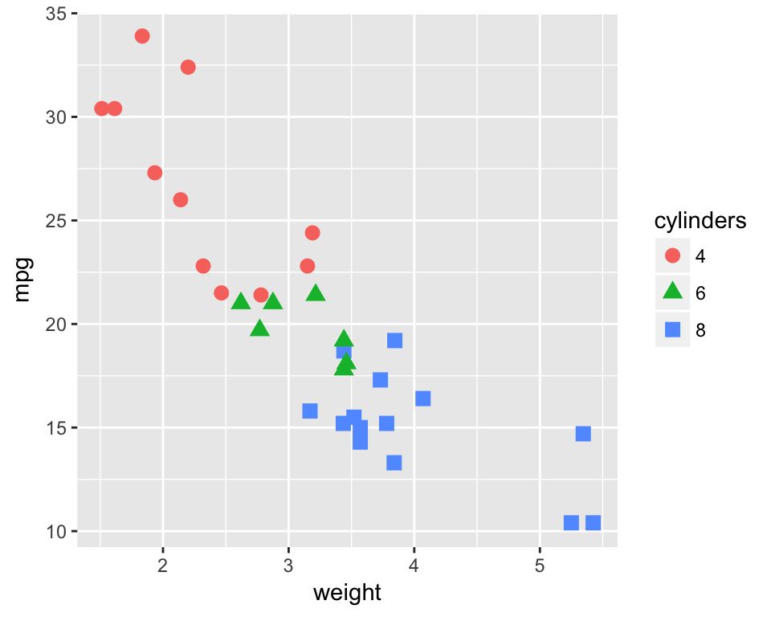

# Other grammatical elements: statistics

Behind the scenes, R may need to do some transformation on the dataset to make the graphic.

- **Each geometry has a default statistic, usually good enough**

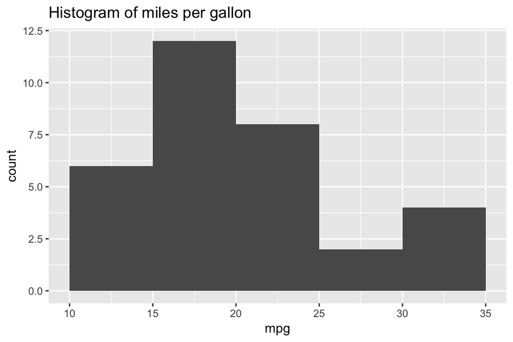

# Other grammatical elements: position

Sometimes we need to tweak the position of the geometric elements because they obscure each other.

- E.g. jitter: randomly shifting points slightly

**Only 9 data points??**

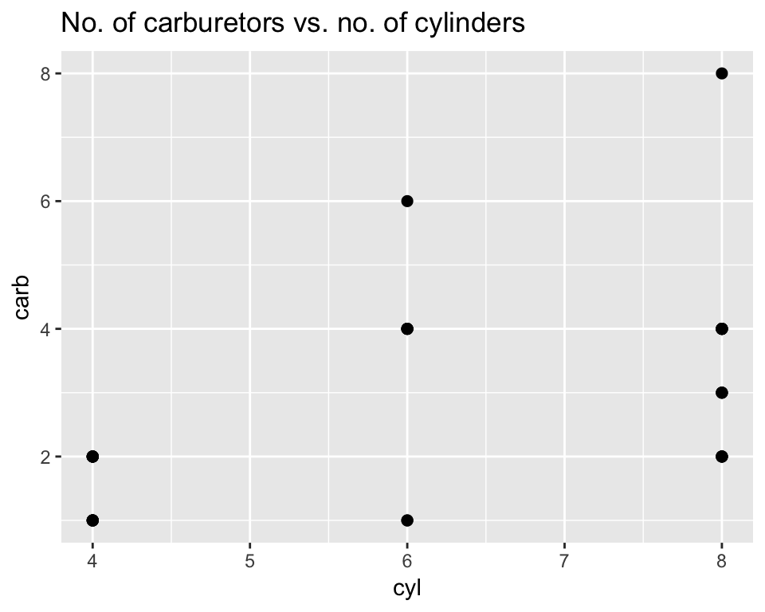

**Much better**

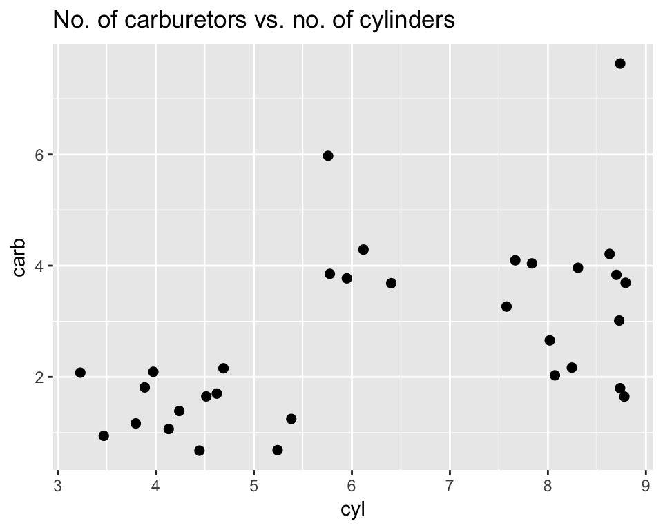

# Other grammatical elements: facets

- Plotting different parts of our data on different canvases
- We can facet by rows and/or columns

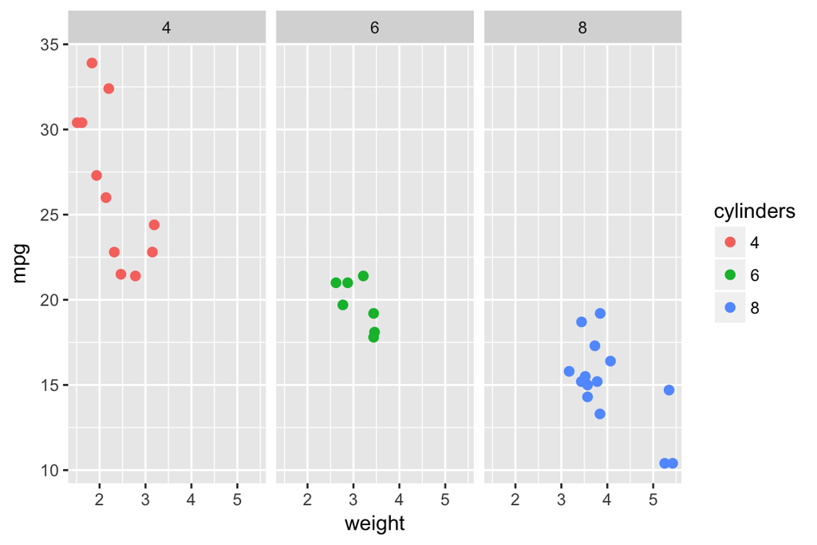

# Other grammatical elements: scales

- Aesthetics only tell you which column corresponds with which aesthetic (e.g. cylinder -> color)
- Does not tell you which color should represent which cylinder value
- **Scales** define that for you

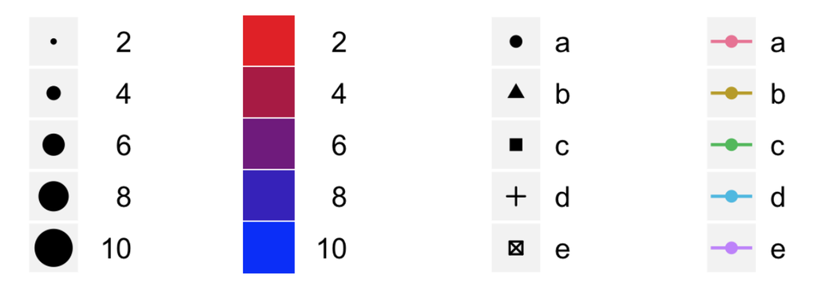

Examples of scales (Source: [A Layered Grammar of Graphics](http://vita.had.co.nz/papers/layered-grammar.pdf))

# Scales example: colors

**Manually chosen colors**

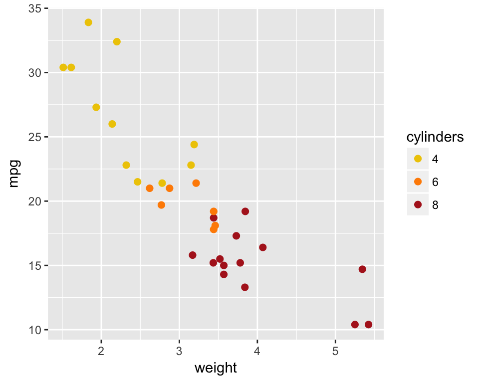

# Scales example: x- & y-axes

**Manually chosen axis limits**

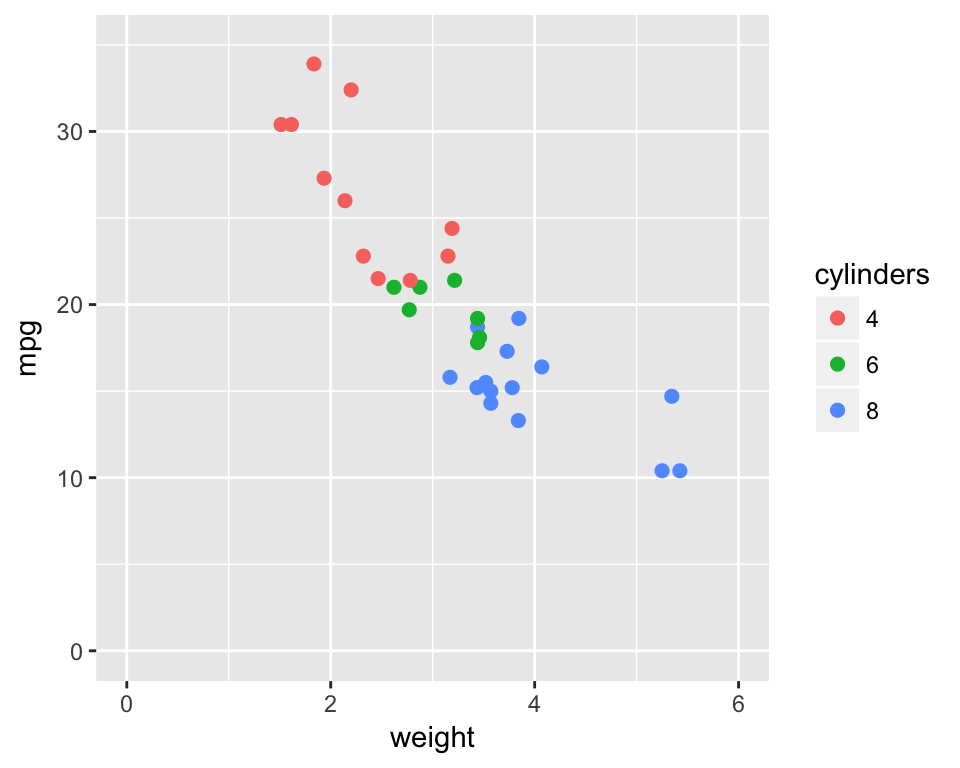

# Other grammatical elements: Themes

Refers to all non-data ink

- Titles, axis ticks & labels, background color, legend, etc.
- Can manually set each item, or use preset themes

**Minimal theme**

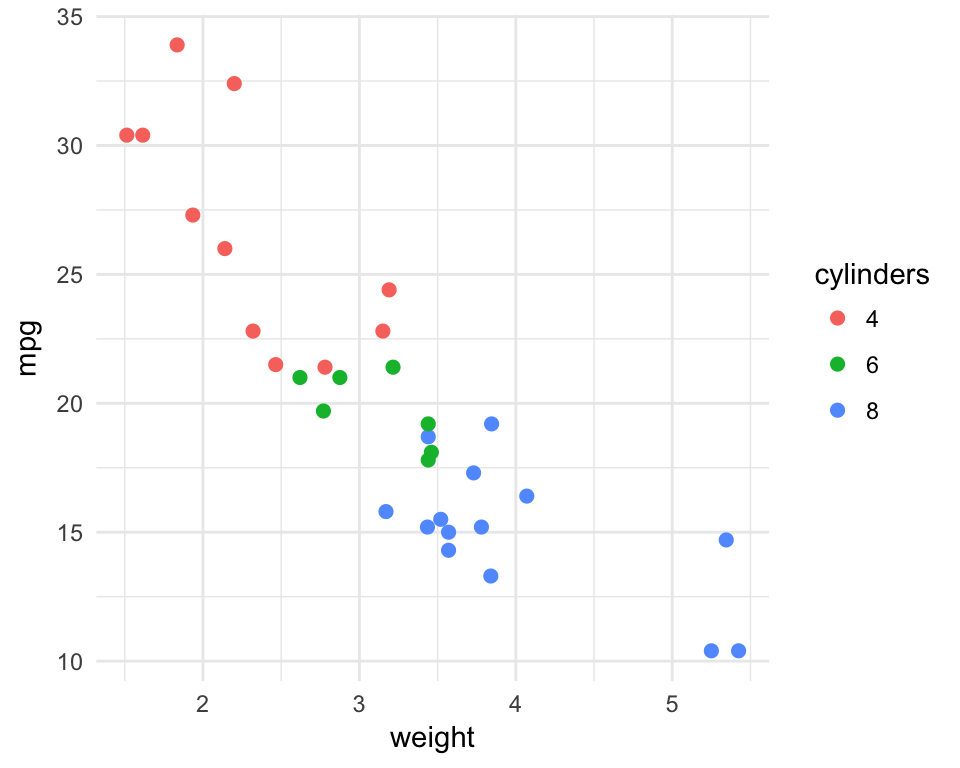

# More pre-set themes

**Classic theme**

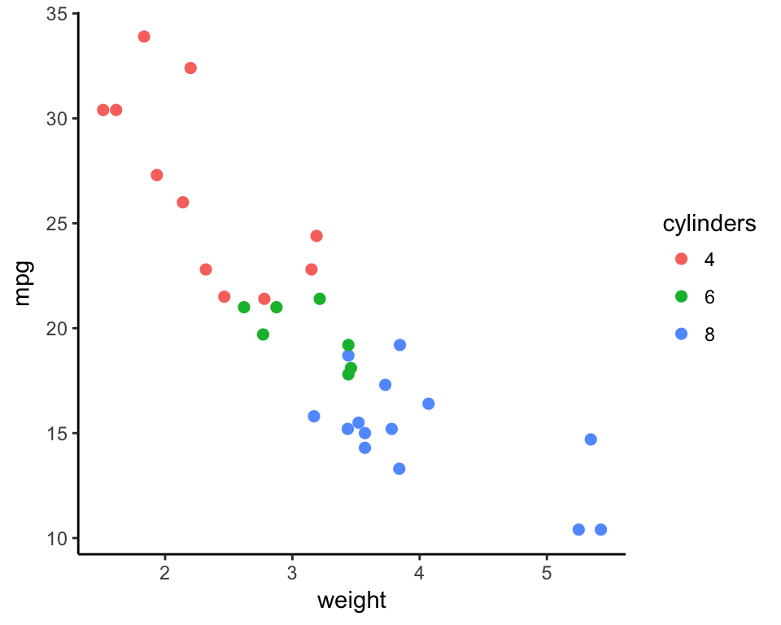

**Dark theme**

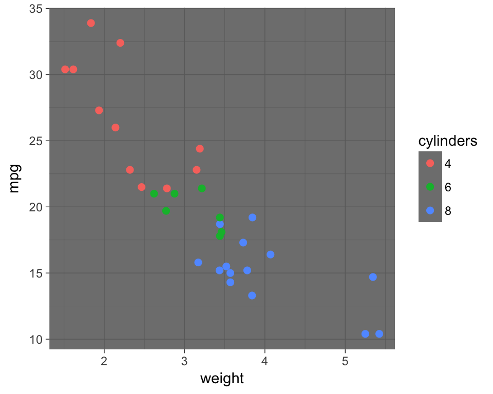

# Combining multiple plots into one graphic: Layers

We can have more than one **layer** in a graphic.

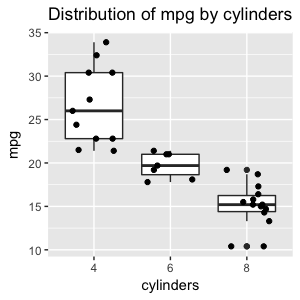

**=**

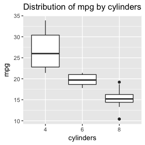

**+**

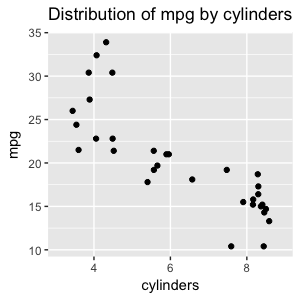

Each layer contains:

- 1 dataset, 1 **geom**etric object, **aes**thetic mappings, 1 statistic (default usually ok), 1 position (default usually ok)

# Recap: Elements of a graphic

One graphic contains:

- 1 or more layers
  - Each layer has 1 dataset, 1 **geom**etric object, **aes**thetic mappings, 1 statistic (default usually ok), 1 position (default usually ok)
- 1 scale for each aesthetic mapping (defaults usually ok)
- 1 coordinate system (default usually ok)
- facet specification (if any)

# `ggplot2` code: take 1

Making use of `ggplot`’s sensible defaults:

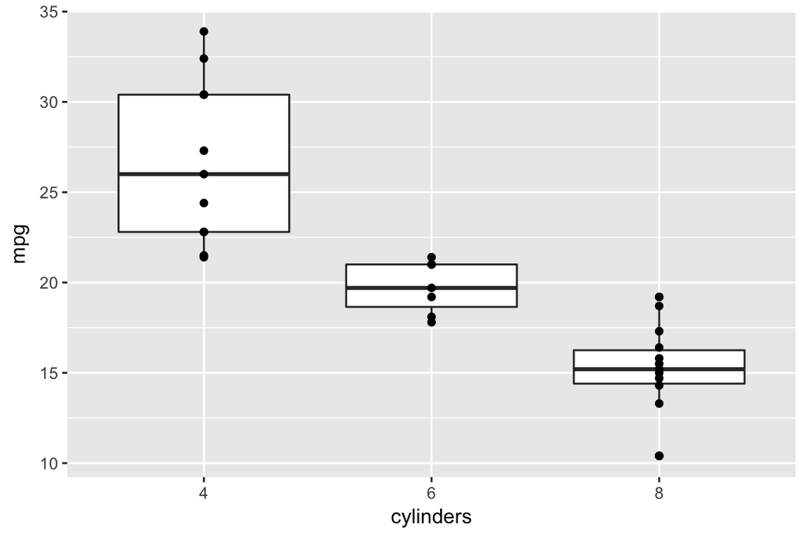

```r
ggplot() +
    geom_boxplot(data = df, mapping = aes(x = cylinders, y = mpg)) +
    geom_point(data = df, mapping = aes(x = cylinders, y = mpg))
```

# `ggplot2` code: take 2

Using jitter to avoid “overplotting”:

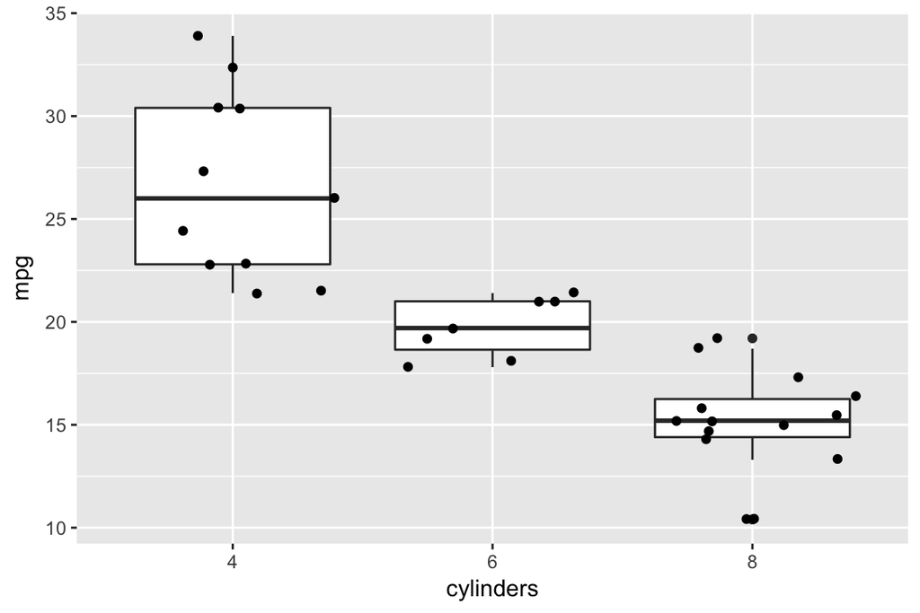

```r
ggplot() +
    geom_boxplot(data = df, mapping = aes(x = cylinders, y = mpg)) +
    geom_point(data = df, mapping = aes(x = cylinders, y = mpg),
               position = "jitter")
```